# R-assignment

Ahmed_Raslan

2023-03-12

# BCB546_R_assignemnt_final

## Data Inspection

Download files

```r
library(tidyverse)
url <- "https://raw.githubusercontent.com/EEOB-BioData/BCB546_Spring2023/main/assignments/UNIX_Assignment/fang_et_al_genotypes.txt"
 download.file(url, destfile = "fang_et_al_genotypes.txt")

url <- "https://raw.githubusercontent.com/EEOB-BioData/BCB546_Spring2023/main/assignments/UNIX_Assignment/snp_position.txt"
 download.file(url, destfile = "snp_position.txt")
```

Reading files

```r
library(readr)
readable_fang_et_al_genotypes <- read_tsv("fang_et_al_genotypes.txt")
write.csv(readable_fang_et_al_genotypes, "readable_fang_et_al_genotypes.csv", row.names = FALSE)
readable_snp_position <- read_tsv("snp_position.txt")
write.csv(readable_snp_position, "readable_snp_positio.csv", row.names = FALSE)
```

Inspection

```r
View(readable_snp_position)
View(readable_fang_et_al_genotypes)
head(readable_fang_et_al_genotypes)
```

```
## # A tibble: 6 × 986
##   Sampl…¹ JG_OTU Group abph1…² abph1…³ ae1.3 ae1.4 ae1.5 an1.4 ba1.6 ba1.9 bt2.5
##   <chr>   <chr>  <chr> <chr>   <chr>   <chr> <chr> <chr> <chr> <chr> <chr> <chr>
## 1 SL-15   T-aus… TRIPS ?/?     ?/?     T/T   G/G   T/T   C/C   ?/?   G/G   ?/?
## 2 SL-16   T-aus… TRIPS ?/?     ?/?     T/T   ?/?   T/T   C/C   A/G   G/G   ?/?
## 3 SL-11   T-bra… TRIPS ?/?     ?/?     T/T   G/G   T/T   ?/?   G/G   G/G   C/C
## 4 SL-12   T-bra… TRIPS ?/?     ?/?     T/T   G/G   T/T   C/C   G/G   G/G   C/C
## 5 SL-18   T-cund TRIPS ?/?     ?/?     T/T   G/G   T/T   C/C   ?/?   G/G   ?/?
## 6 SL-2    T-dac… TRIPS ?/?     ?/?     T/T   G/G   T/T   C/C   A/G   G/G   ?/?
## # … with 974 more variables: bt2.7 <chr>, bt2.8 <chr>, Fea2.1 <chr>,
## #   Fea2.5 <chr>, id1.3 <chr>, lg2.11 <chr>, lg2.2 <chr>, pbf1.1 <chr>,
## #   pbf1.2 <chr>, pbf1.3 <chr>, pbf1.5 <chr>, pbf1.6 <chr>, pbf1.7 <chr>,
## #   pbf1.8 <chr>, PZA00003.11 <chr>, PZA00004.2 <chr>, PZA00005.8 <chr>,
## #   PZA00005.9 <chr>, PZA00006.13 <chr>, PZA00006.14 <chr>, PZA00008.1 <chr>,
## #   PZA00010.5 <chr>, PZA00013.10 <chr>, PZA00013.11 <chr>, PZA00013.9 <chr>,
## #   PZA00015.4 <chr>, PZA00017.1 <chr>, PZA00018.5 <chr>, PZA00029.11 <chr>, …
```

```r
head(readable_snp_position)
```

```
## # A tibble: 6 × 15
##   SNP_ID   cdv_m…¹ Chrom…² Posit…³ alt_pos mult_…⁴ ampli…⁵ cdv_m…⁶ gene  candi…⁷
##   <chr>      <dbl> <chr>   <chr>   <chr>   <chr>   <chr>   <chr>   <chr> <chr>
## 1 abph1.20    5976 2       274034… <NA>    <NA>    abph1   AB0422… abph1 candid…
## 2 abph1.22    5978 2       274038… <NA>    <NA>    abph1   AB0422… abph1 candid…
## 3 ae1.3       6605 5       167889… <NA>    <NA>    ae1     ae1     ae1   candid…
## 4 ae1.4       6606 5       167889… <NA>    <NA>    ae1     ae1     ae1   candid…
## 5 ae1.5       6607 5       167889… <NA>    <NA>    ae1     ae1     ae1   candid…
## 6 an1.4       5982 1       240498… <NA>    <NA>    an1     an1     an1   candid…
## # … with 5 more variables: Genaissance_daa_id <dbl>, Sequenom_daa_id <dbl>,
## #   count_amplicons <dbl>, count_cmf <dbl>, count_gene <dbl>, and abbreviated
## #   variable names ¹cdv_marker_id, ²Chromosome, ³Position, ⁴mult_positions,
## #   ⁵amplicon, ⁶cdv_map_feature.name, ⁷`candidate/random`
```

```r
tail (readable_snp_position)
```

```
## # A tibble: 6 × 15
##   SNP_ID cdv_mar…¹ Chrom…² Posit…³ alt_pos mult_…⁴ ampli…⁵ cdv_m…⁶ gene  candi…⁷
##   <chr>      <dbl> <chr>   <chr>   <chr>   <chr>   <chr>   <chr>   <chr> <chr>
## 1 zap1.2      3514 2       233128… <NA>    <NA>    zap1    L46400  zap1  candid…
## 2 zen1.1      3519 unknown unknown <NA>    <NA>    zen1    CF6490… zen1  candid…
## 3 zen1.2      3520 unknown unknown <NA>    <NA>    zen1    CF6490… zen1  candid…
## 4 zen1.4      3521 unknown unknown <NA>    <NA>    zen1    CF6490… zen1  candid…
## 5 zfl2.6      6463 2       125432… <NA>    <NA>    zfl2    zfl2    zfl2  candid…
## 6 zmm3.4      3527 9       169663… <NA>    <NA>    zmm3    Y09301  zmm3  candid…
## # … with 5 more variables: Genaissance_daa_id <dbl>, Sequenom_daa_id <dbl>,
## #   count_amplicons <dbl>, count_cmf <dbl>, count_gene <dbl>, and abbreviated
## #   variable names ¹cdv_marker_id, ²Chromosome, ³Position, ⁴mult_positions,
## #   ⁵amplicon, ⁶cdv_map_feature.name, ⁷`candidate/random`
```

```r
tail (readable_fang_et_al_genotypes)
```

```
## # A tibble: 6 × 986
##   Sampl…¹ JG_OTU Group abph1…² abph1…³ ae1.3 ae1.4 ae1.5 an1.4 ba1.6 ba1.9 bt2.5
##   <chr>   <chr>  <chr> <chr>   <chr>   <chr> <chr> <chr> <chr> <chr> <chr> <chr>
## 1 SYN262  Zmm-I… ZMMIL C/C     A/A     T/T   G/G   C/C   C/C   G/G   G/G   C/C
## 2 S0398   Zmm-I… ZMMIL G/G     A/A     T/T   G/G   C/C   C/C   G/G   G/G   C/C
## 3 S1636   Zmm-I… ZMMIL G/G     A/A     T/T   G/G   C/C   C/C   G/G   G/G   C/C
## 4 CU0201  Zmm-I… ZMMIL C/C     A/A     T/T   G/G   C/C   C/C   G/G   G/G   C/C
## 5 S0215   Zmm-I… ZMMIL G/G     A/A     T/T   ?/?   C/C   C/C   G/G   G/G   C/C
## 6 CU0202  Zmm-I… ZMMIL C/C     A/A     T/T   G/G   C/C   C/C   ?/?   G/G   C/C
## # … with 974 more variables: bt2.7 <chr>, bt2.8 <chr>, Fea2.1 <chr>,
## #   Fea2.5 <chr>, id1.3 <chr>, lg2.11 <chr>, lg2.2 <chr>, pbf1.1 <chr>,
## #   pbf1.2 <chr>, pbf1.3 <chr>, pbf1.5 <chr>, pbf1.6 <chr>, pbf1.7 <chr>,
## #   pbf1.8 <chr>, PZA00003.11 <chr>, PZA00004.2 <chr>, PZA00005.8 <chr>,
## #   PZA00005.9 <chr>, PZA00006.13 <chr>, PZA00006.14 <chr>, PZA00008.1 <chr>,
## #   PZA00010.5 <chr>, PZA00013.10 <chr>, PZA00013.11 <chr>, PZA00013.9 <chr>,
## #   PZA00015.4 <chr>, PZA00017.1 <chr>, PZA00018.5 <chr>, PZA00029.11 <chr>, …
```

```r
str(readable_fang_et_al_genotypes)
```

```
## spc_tbl_ [2,782 × 986] (S3: spec_tbl_df/tbl_df/tbl/data.frame)
##  $ Sample_ID     : chr [1:2782] "SL-15" "SL-16" "SL-11" "SL-12" ...
##  $ JG_OTU        : chr [1:2782] "T-aust-1" "T-aust-2" "T-brav-1" "T-brav-2" ...
##  $ Group         : chr [1:2782] "TRIPS" "TRIPS" "TRIPS" "TRIPS" ...
##  $ abph1.20      : chr [1:2782] "?/?" "?/?" "?/?" "?/?" ...
##  $ abph1.22      : chr [1:2782] "?/?" "?/?" "?/?" "?/?" ...
##  $ ae1.3         : chr [1:2782] "T/T" "T/T" "T/T" "T/T" ...
##  $ ae1.4         : chr [1:2782] "G/G" "?/?" "G/G" "G/G" ...
##  $ ae1.5         : chr [1:2782] "T/T" "T/T" "T/T" "T/T" ...
##  $ an1.4         : chr [1:2782] "C/C" "C/C" "?/?" "C/C" ...
##  $ ba1.6         : chr [1:2782] "?/?" "A/G" "G/G" "G/G" ...
##  $ ba1.9         : chr [1:2782] "G/G" "G/G" "G/G" "G/G" ...
##  $ bt2.5         : chr [1:2782] "?/?" "?/?" "C/C" "C/C" ...
##  $ bt2.7         : chr [1:2782] "A/A" "A/A" "A/A" "A/A" ...
##  $ bt2.8         : chr [1:2782] "?/?" "?/?" "?/?" "?/?" ...
##  $ Fea2.1        : chr [1:2782] "C/C" "C/C" "?/?" "?/?" ...
##  $ Fea2.5        : chr [1:2782] "A/A" "A/A" "A/A" "A/A" ...
##  $ id1.3         : chr [1:2782] "T/T" "T/T" "T/T" "T/T" ...
##  $ lg2.11        : chr [1:2782] "C/C" "C/C" "C/C" "C/C" ...
##  $ lg2.2         : chr [1:2782] "A/A" "A/A" "A/A" "A/A" ...
##  $ pbf1.1        : chr [1:2782] "?/?" "T/T" "T/T" "T/T" ...
##  $ pbf1.2        : chr [1:2782] "?/?" "?/?" "?/?" "?/?" ...
##  $ pbf1.3        : chr [1:2782] "?/?" "?/?" "?/?" "?/?" ...
##  $ pbf1.5        : chr [1:2782] "?/?" "?/?" "A/A" "A/A" ...
##  $ pbf1.6        : chr [1:2782] "?/?" "?/?" "?/?" "?/?" ...
##  $ pbf1.7        : chr [1:2782] "C/C" "C/C" "C/C" "C/C" ...
##  $ pbf1.8        : chr [1:2782] "C/C" "C/C" "C/C" "C/C" ...
##  $ PZA00003.11   : chr [1:2782] "?/?" "?/?" "C/C" "?/?" ...
##  $ PZA00004.2    : chr [1:2782] "T/T" "T/T" "?/?" "T/T" ...
##  $ PZA00005.8    : chr [1:2782] "G/G" "G/G" "G/G" "G/G" ...
##  $ PZA00005.9    : chr [1:2782] "C/C" "C/C" "C/C" "C/C" ...
##  $ PZA00006.13   : chr [1:2782] "A/A" "A/A" "A/A" "A/A" ...
##  $ PZA00006.14   : chr [1:2782] "?/?" "G/G" "G/G" "G/G" ...
##  $ PZA00008.1    : chr [1:2782] "C/C" "C/C" "C/C" "C/C" ...
##  $ PZA00010.5    : chr [1:2782] "C/C" "C/C" "C/C" "C/C" ...
##  $ PZA00013.10   : chr [1:2782] "A/A" "A/A" "A/A" "A/A" ...
##  $ PZA00013.11   : chr [1:2782] "C/C" "C/C" "C/T" "C/T" ...
##  $ PZA00013.9    : chr [1:2782] "T/T" "T/T" "T/T" "T/T" ...
##  $ PZA00015.4    : chr [1:2782] "?/?" "?/?" "?/?" "?/?" ...
##  $ PZA00017.1    : chr [1:2782] "G/G" "G/G" "G/G" "G/G" ...
```

[output cut: 1036 more lines]

```
##   ..   tb1.18 = col_character(),
##   ..   tb1.19 = col_character(),
##   ..   tb1.5 = col_character(),
##   ..   te1.3 = col_character(),
##   ..   te1.4 = col_character(),
##   ..   zagl1.1 = col_character(),
##   ..   zagl1.6 = col_character(),
##   ..   zap1.2 = col_character(),
##   ..   zen1.1 = col_character(),
##   ..   zen1.2 = col_character(),
##   ..   zen1.4 = col_character(),
##   ..   zfl2.6 = col_character(),
##   ..   zmm3.4 = col_character()
##   .. )
##  - attr(*, "problems")=<externalptr>
```

```r
str(readable_snp_position)
```

```
## spc_tbl_ [983 × 15] (S3: spec_tbl_df/tbl_df/tbl/data.frame)
##  $ SNP_ID              : chr [1:983] "abph1.20" "abph1.22" "ae1.3" "ae1.4" ...
##  $ cdv_marker_id       : num [1:983] 5976 5978 6605 6606 6607 ...
##  $ Chromosome          : chr [1:983] "2" "2" "5" "5" ...
##  $ Position            : chr [1:983] "27403404" "27403892" "167889790" "167889682" ...
##  $ alt_pos             : chr [1:983] NA NA NA NA ...
##  $ mult_positions      : chr [1:983] NA NA NA NA ...
##  $ amplicon            : chr [1:983] "abph1" "abph1" "ae1" "ae1" ...
##  $ cdv_map_feature.name: chr [1:983] "AB042260" "AB042260" "ae1" "ae1" ...
##  $ gene                : chr [1:983] "abph1" "abph1" "ae1" "ae1" ...
##  $ candidate/random    : chr [1:983] "candidate" "candidate" "candidate" "candidate" ...
##  $ Genaissance_daa_id  : num [1:983] 8393 8394 8395 8396 8397 ...
##  $ Sequenom_daa_id     : num [1:983] 10474 10475 10477 10478 10479 ...
##  $ count_amplicons     : num [1:983] 1 0 1 0 0 1 1 0 1 0 ...
##  $ count_cmf           : num [1:983] 1 0 1 0 0 1 0 0 1 0 ...
##  $ count_gene          : num [1:983] 1 0 1 0 0 1 1 0 1 0 ...
##  - attr(*, "spec")=
##   .. cols(
##   ..   SNP_ID = col_character(),
##   ..   cdv_marker_id = col_double(),
##   ..   Chromosome = col_character(),
##   ..   Position = col_character(),
##   ..   alt_pos = col_character(),
##   ..   mult_positions = col_character(),
##   ..   amplicon = col_character(),
##   ..   cdv_map_feature.name = col_character(),
##   ..   gene = col_character(),
##   ..   `candidate/random` = col_character(),
##   ..   Genaissance_daa_id = col_double(),
##   ..   Sequenom_daa_id = col_double(),
##   ..   count_amplicons = col_double(),
##   ..   count_cmf = col_double(),
##   ..   count_gene = col_double()
##   .. )
##  - attr(*, "problems")=<externalptr>
```

```r
summary(readable_fang_et_al_genotypes)
```

```
##   Sample_ID            JG_OTU             Group             abph1.20
##  Length:2782        Length:2782        Length:2782        Length:2782
##  Class :character   Class :character   Class :character   Class :character
##  Mode  :character   Mode  :character   Mode  :character   Mode  :character
##    abph1.22            ae1.3              ae1.4              ae1.5
##  Length:2782        Length:2782        Length:2782        Length:2782
##  Class :character   Class :character   Class :character   Class :character
##  Mode  :character   Mode  :character   Mode  :character   Mode  :character
##     an1.4              ba1.6              ba1.9              bt2.5
##  Length:2782        Length:2782        Length:2782        Length:2782
##  Class :character   Class :character   Class :character   Class :character
##  Mode  :character   Mode  :character   Mode  :character   Mode  :character
##     bt2.7              bt2.8              Fea2.1             Fea2.5
##  Length:2782        Length:2782        Length:2782        Length:2782
##  Class :character   Class :character   Class :character   Class :character
##  Mode  :character   Mode  :character   Mode  :character   Mode  :character
##     id1.3              lg2.11             lg2.2              pbf1.1
##  Length:2782        Length:2782        Length:2782        Length:2782
##  Class :character   Class :character   Class :character   Class :character
##  Mode  :character   Mode  :character   Mode  :character   Mode  :character
##     pbf1.2             pbf1.3             pbf1.5             pbf1.6
##  Length:2782        Length:2782        Length:2782        Length:2782
##  Class :character   Class :character   Class :character   Class :character
##  Mode  :character   Mode  :character   Mode  :character   Mode  :character
##     pbf1.7             pbf1.8          PZA00003.11         PZA00004.2
##  Length:2782        Length:2782        Length:2782        Length:2782
##  Class :character   Class :character   Class :character   Class :character
##  Mode  :character   Mode  :character   Mode  :character   Mode  :character
##   PZA00005.8         PZA00005.9        PZA00006.13        PZA00006.14
##  Length:2782        Length:2782        Length:2782        Length:2782
##  Class :character   Class :character   Class :character   Class :character
##  Mode  :character   Mode  :character   Mode  :character   Mode  :character
##   PZA00008.1         PZA00010.5        PZA00013.10        PZA00013.11
##  Length:2782        Length:2782        Length:2782        Length:2782
##  Class :character   Class :character   Class :character   Class :character
##  Mode  :character   Mode  :character   Mode  :character   Mode  :character
##   PZA00013.9         PZA00015.4         PZA00017.1         PZA00018.5
##  Length:2782        Length:2782        Length:2782        Length:2782
##  Class :character   Class :character   Class :character   Class :character
##  Mode  :character   Mode  :character   Mode  :character   Mode  :character
```

[output cut: 933 more lines]

```
##  Length:2782        Length:2782        Length:2782        Length:2782
##  Class :character   Class :character   Class :character   Class :character
##  Mode  :character   Mode  :character   Mode  :character   Mode  :character
##     te1.3              te1.4             zagl1.1            zagl1.6
##  Length:2782        Length:2782        Length:2782        Length:2782
##  Class :character   Class :character   Class :character   Class :character
##  Mode  :character   Mode  :character   Mode  :character   Mode  :character
##     zap1.2             zen1.1             zen1.2             zen1.4
##  Length:2782        Length:2782        Length:2782        Length:2782
##  Class :character   Class :character   Class :character   Class :character
##  Mode  :character   Mode  :character   Mode  :character   Mode  :character
##     zfl2.6             zmm3.4
##  Length:2782        Length:2782
##  Class :character   Class :character
##  Mode  :character   Mode  :character
```

```r
summary(readable_snp_position)
```

```
##     SNP_ID          cdv_marker_id    Chromosome          Position
##  Length:983         Min.   : 3463   Length:983         Length:983
##  Class :character   1st Qu.: 3978   Class :character   Class :character
##  Mode  :character   Median : 5723   Mode  :character   Mode  :character
##                     Mean   : 5925
##                     3rd Qu.: 6629
##                     Max.   :12480
##    alt_pos          mult_positions       amplicon         cdv_map_feature.name
##  Length:983         Length:983         Length:983         Length:983
##  Class :character   Class :character   Class :character   Class :character
##  Mode  :character   Mode  :character   Mode  :character   Mode  :character
##
##
##
##      gene           candidate/random   Genaissance_daa_id Sequenom_daa_id
##  Length:983         Length:983         Min.   : 7649      Min.   :10474
##  Class :character   Class :character   1st Qu.: 7906      1st Qu.:10784
##  Mode  :character   Mode  :character   Median : 8173      Median :11110
##                                        Mean   : 8524      Mean   :11122
##                                        3rd Qu.: 9834      3rd Qu.:11420
##                                        Max.   :10104      Max.   :11829
##  count_amplicons    count_cmf        count_gene
##  Min.   :0.0000   Min.   :0.0000   Min.   :0.0000
##  1st Qu.:0.0000   1st Qu.:0.0000   1st Qu.:0.0000
##  Median :1.0000   Median :1.0000   Median :1.0000
##  Mean   :0.5768   Mean   :0.5483   Mean   :0.5565
##  3rd Qu.:1.0000   3rd Qu.:1.0000   3rd Qu.:1.0000
##  Max.   :1.0000   Max.   :1.0000   Max.   :1.0000
```

```r
dim(readable_fang_et_al_genotypes)
```

```
## [1] 2782  986
```

```r
dim(readable_snp_position)
```

```
## [1] 983  15
```

```r
names(readable_fang_et_al_genotypes)
```

```
##   [1] "Sample_ID"      "JG_OTU"         "Group"          "abph1.20"
##   [5] "abph1.22"       "ae1.3"          "ae1.4"          "ae1.5"
##   [9] "an1.4"          "ba1.6"          "ba1.9"          "bt2.5"
##  [13] "bt2.7"          "bt2.8"          "Fea2.1"         "Fea2.5"
##  [17] "id1.3"          "lg2.11"         "lg2.2"          "pbf1.1"
##  [21] "pbf1.2"         "pbf1.3"         "pbf1.5"         "pbf1.6"
##  [25] "pbf1.7"         "pbf1.8"         "PZA00003.11"    "PZA00004.2"
##  [29] "PZA00005.8"     "PZA00005.9"     "PZA00006.13"    "PZA00006.14"
##  [33] "PZA00008.1"     "PZA00010.5"     "PZA00013.10"    "PZA00013.11"
##  [37] "PZA00013.9"     "PZA00015.4"     "PZA00017.1"     "PZA00018.5"
##  [41] "PZA00029.11"    "PZA00029.12"    "PZA00030.11"    "PZA00031.5"
##  [45] "PZA00041.3"     "PZA00042.2"     "PZA00042.5"     "PZA00043.7"
##  [49] "PZA00045.1"     "PZA00047.2"     "PZA00049.12"    "PZA00050.9"
##  [53] "PZA00051.2"     "PZA00058.5"     "PZA00058.6"     "PZA00060.2"
##  [57] "PZA00061.1"     "PZA00065.2"     "PZA00069.4"     "PZA00070.5"
```

[output cut: 232 more lines]

```r
names(readable_snp_position)
```

```
##  [1] "SNP_ID"               "cdv_marker_id"        "Chromosome"
##  [4] "Position"             "alt_pos"              "mult_positions"
##  [7] "amplicon"             "cdv_map_feature.name" "gene"
## [10] "candidate/random"     "Genaissance_daa_id"   "Sequenom_daa_id"
## [13] "count_amplicons"      "count_cmf"            "count_gene"
```

```r
nrow(readable_fang_et_al_genotypes)
```

```
## [1] 2782
```

```r
nrow(readable_snp_position)
```

```
## [1] 983
```

```r
ncol(readable_fang_et_al_genotypes)
```

```
## [1] 986
```

```r
ncol(readable_snp_position)
```

```
## [1] 15
```

## Data processing

Extracting columns; SNP_ID, Chromosome and Position

```r
library(dplyr)
cut_snp_position <- select(readable_snp_position, SNP_ID, Chromosome, Position)
write.csv(cut_snp_position, "cut_snp_position.csv", row.names = FALSE)
```

## Maize

Extracting maize groups, transposing output file, then taking off the first 2 rows.

```r
library(stringr)
maize_fang <- readable_fang_et_al_genotypes %>%
    filter(if_any(everything(), ~ str_detect(as.character(.), "Group|ZMMIL|ZMMLR|ZMMMR")))
     write.csv(maize_fang, "maize_fang.csv", row.names = FALSE)
transposed_maize_fang <- t(maize_fang)
write.csv(transposed_maize_fang, "transposed_maize_fang.csv", row.names = FALSE)
headsoff_transposed_maize_fang <- transposed_maize_fang[-c(1:2),]
write.csv(headsoff_transposed_maize_fang, "headsoff_transposed_maize_fang.csv", row.names = FALSE)
```

Tidying ” headsoff_transposed_maize_fang” so the first row becomes the columns names row.

Joining “cut_snp_position” and “headsoff_transposed_maize_fang”

Extracting “multiple” and “unknown” matches from the output file (joined_maize_snp).

```r
colnames(headsoff_transposed_maize_fang) <- headsoff_transposed_maize_fang[1, ]
headsoff_transposed_maize_fang <- headsoff_transposed_maize_fang[-1, ]





joined_maize_snp <- cbind(cut_snp_position, headsoff_transposed_maize_fang)
row.names(joined_maize_snp) <- NULL
write.csv(joined_maize_snp, "joined_maize_snp.csv", row.names = FALSE)


unknown_joined_maize_snp <- grepl("unknown", joined_maize_snp$Chromosome) | grepl("unknown", joined_maize_snp$Position)
unknown_joined_maize_snp <- joined_maize_snp[unknown_joined_maize_snp, ]
write.csv(unknown_joined_maize_snp, "unknown_joined_maize_snp.csv", row.names = FALSE)


multiple_joined_maize_snp    <- grepl("multiple", joined_maize_snp$Chromosome) | grepl("multiple", joined_maize_snp$Position)
multiple_joined_maize_snp <- joined_maize_snp[multiple_joined_maize_snp, ]
write.csv(multiple_joined_maize_snp, "multiple_joined_maize_snp.csv", row.names = FALSE)
```

Extracting each of the 10 chromosomes. repeating the next chunk for all 10 chromosomes

```r
maize1_snp    <- grepl("^1$", joined_maize_snp$Chromosome)
maize1_snp <- joined_maize_snp[maize1_snp, ]
write.csv(maize1_snp, "maize1_snp.csv", row.names = FALSE)
```

Setting the position column as numeric, then arranging in decreasing order based on “Position”. Repeat for all 10 chromosomes

```r
maize1_snp$Position <- as.numeric(maize1_snp$Position)
maize1_snp <- maize1_snp[order(desc(maize1_snp$Position)),]
write.csv(maize1_snp, "down_maize1_snp.csv", row.names = FALSE)
```

Replacing ?/? with --. Repeat for all 10 down chromosmes

```r
down_maize1_snp <- read.csv("down_maize1_snp.csv")
down_maize1_snp <- read.csv("down_maize1_snp.csv")
down_maize1_snp[down_maize1_snp == "?/?"] <- "-/-"
write.csv(down_maize1_snp, "edited-down_maize1_snps.csv", row.names = FALSE)
```

Arranging in increasing order based on “Position”. Repeat for all 10 chromosomes

```r
maize1_snp <- maize1_snp[order(maize1_snp$Position),]
write.csv(maize1_snp, "up_maize1_snp.csv", row.names = FALSE)
```

## Teosinte

Running the same commands for teosinte data processing.

```r
teosinte_fang <- readable_fang_et_al_genotypes %>%
     filter(if_any(everything(), ~ str_detect(as.character(.), "Group|ZMPBA|ZMPIL|ZMPJA")))
write.csv(teosinte_fang, "teosinte_fang.csv", row.names = FALSE)
transposed_teosinte_fang <- t(teosinte_fang)
write.csv(transposed_teosinte_fang, "transposed_teosinte_fang.csv", row.names = FALSE)
headsoff_transposed_teosinte_fang <- transposed_teosinte_fang[-c(1:2),]
write.csv(headsoff_transposed_teosinte_fang, "headsoff_transposed_teosinte_fang.csv", row.names = FALSE)
colnames(headsoff_transposed_teosinte_fang) <- headsoff_transposed_teosinte_fang[1, ]
headsoff_transposed_teosinte_fang <- headsoff_transposed_teosinte_fang[-1, ]
joined_teosinte_snp <- cbind(cut_snp_position, headsoff_transposed_teosinte_fang)
row.names(joined_maize_snp) <- NULL
write.csv(joined_teosinte_snp, "joined_teosinte_snp.csv", row.names = FALSE)
unknown_joined_teosinte_snp    <- grepl("unknown", joined_teosinte_snp$Chromosome) | grepl("unknown", joined_teosinte_snp$Position)
unknown_joined_teosinte_snp <- joined_teosinte_snp[unknown_joined_teosinte_snp, ]
write.csv(unknown_joined_teosinte_snp, "unknown_joined_teosinte_snp.csv", row.names = FALSE)
multiple_joined_teosinte_snp    <- grepl("multiple", joined_teosinte_snp$Chromosome) | grepl("multiple", joined_teosinte_snp$Position)
multiple_joined_teosinte_snp <- joined_teosinte_snp[multiple_joined_teosinte_snp, ]
write.csv(multiple_joined_teosinte_snp, "multiple_joined_teosinte_snp.csv", row.names = FALSE)
teosinte1_snp    <- grepl("^1$", joined_teosinte_snp$Chromosome)
teosinte1_snp <- joined_teosinte_snp[teosinte1_snp, ]
write.csv(teosinte1_snp, "teosinte1_snp.csv", row.names = FALSE)
teosinte1_snp$Position <- as.numeric(teosinte1_snp$Position)
teosinte1_snp <- teosinte1_snp[order(desc(teosinte1_snp$Position)),]
write.csv(teosinte1_snp, "down_teosinte1_snp.csv", row.names = FALSE)
teosinte1_snp$Position <- as.numeric(teosinte1_snp$Position)
teosinte1_snp <- teosinte1_snp[order(teosinte1_snp$Position),]
write.csv(teosinte1_snp, "up_teosinte1_snp.csv", row.names = FALSE)
down_teosinte1_snp <- read.csv("down_teosinte1_snp.csv")
down_teosinte1_snp <- read.csv("down_teosinte1_snp.csv")
down_teosinte1_snp[down_teosinte1_snp == "?/?"] <- "-/-"
write.csv(down_teosinte1_snp, "edited-down_teosinte1_snps.csv", row.names = FALSE)
```

## Data visualization

**SNPS distribution on each chromosome**

Setting the position column as numeric and filtering “multiple”, “unknown” and “NA” out of the “Chromosome” and “Position” columns

```r
cut_snp_position$Position <- as.numeric(cut_snp_position$Position)
cut_snp_data_filtered <- cut_snp_position %>%
     filter(Chromosome != "multiple", Chromosome != "unknown", Chromosome != "NA", Position != "unknown", Position != "multiple", Position != "NA" )
```

Creating a density plot of the SNP positions on Chromosome 1 and adds labels and a title to the plot using ggplot2. Repeat for all 10 chromosomes

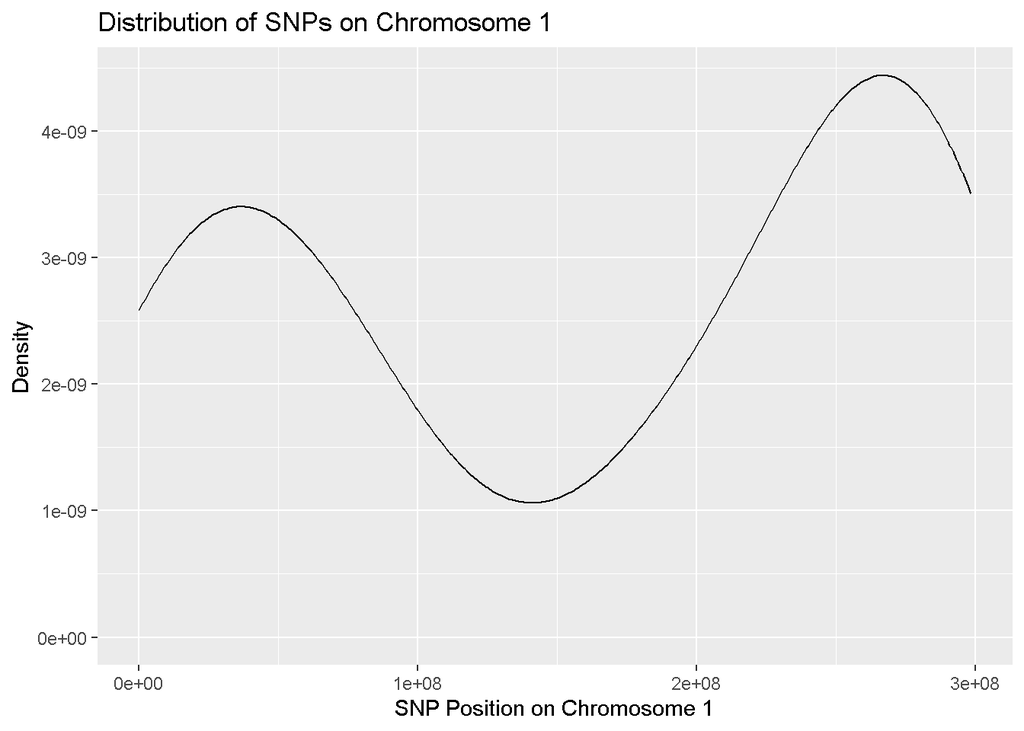

```r
library(ggplot2)
ggplot(data = cut_snp_data_filtered[cut_snp_data_filtered$Chromosome == 1, ], aes(x = Position)) +
     geom_density() +
     labs(x = "SNP Position on Chromosome 1", y = "Density") +
     ggtitle("Distribution of SNPs on Chromosome 1")
```

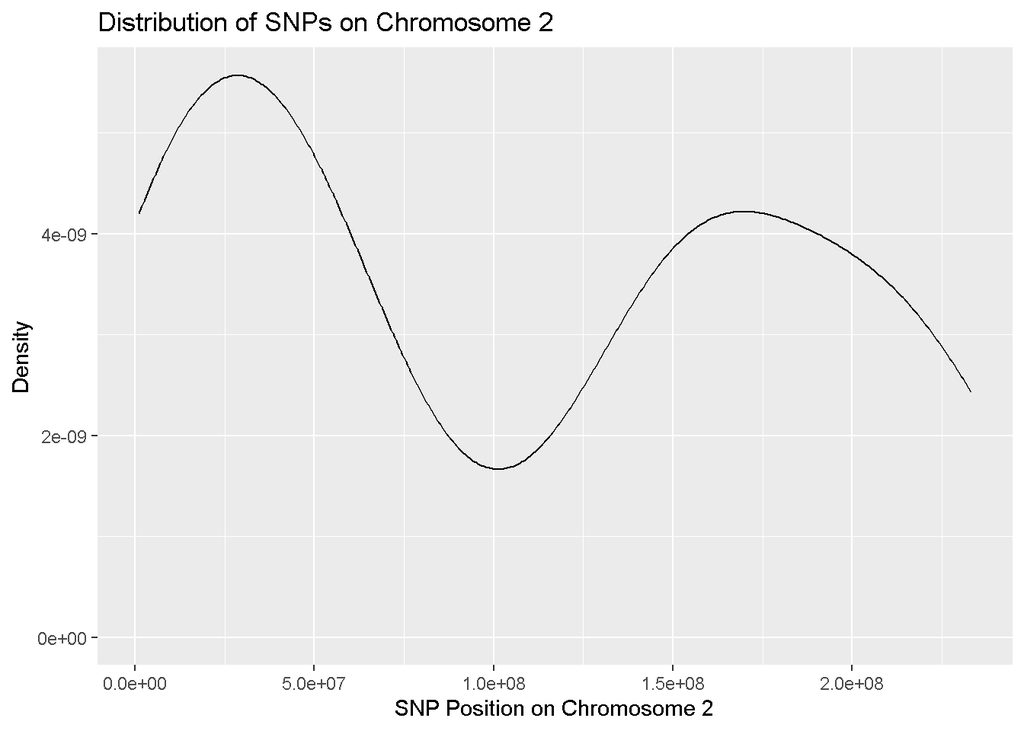

```r
ggplot(data = cut_snp_data_filtered[cut_snp_data_filtered$Chromosome == 2, ], aes(x = Position)) +
     geom_density() +
     labs(x = "SNP Position on Chromosome 2", y = "Density") +
     ggtitle("Distribution of SNPs on Chromosome 2")
```

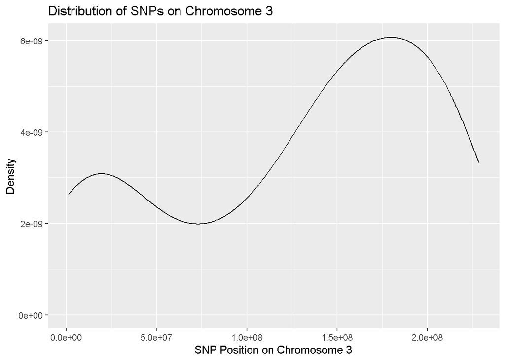

```r
ggplot(data = cut_snp_data_filtered[cut_snp_data_filtered$Chromosome == 3, ], aes(x = Position)) +
     geom_density() +
     labs(x = "SNP Position on Chromosome 3", y = "Density") +
     ggtitle("Distribution of SNPs on Chromosome 3")
```

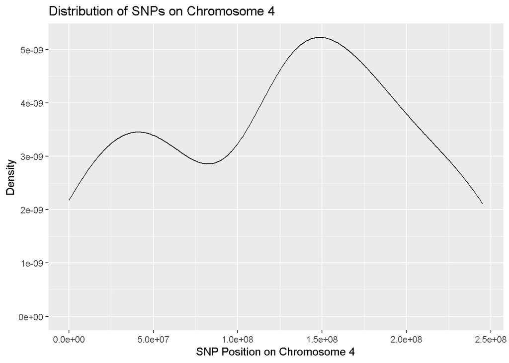

```r
ggplot(data = cut_snp_data_filtered[cut_snp_data_filtered$Chromosome == 4, ], aes(x = Position)) +
     geom_density() +
     labs(x = "SNP Position on Chromosome 4", y = "Density") +
     ggtitle("Distribution of SNPs on Chromosome 4")
```

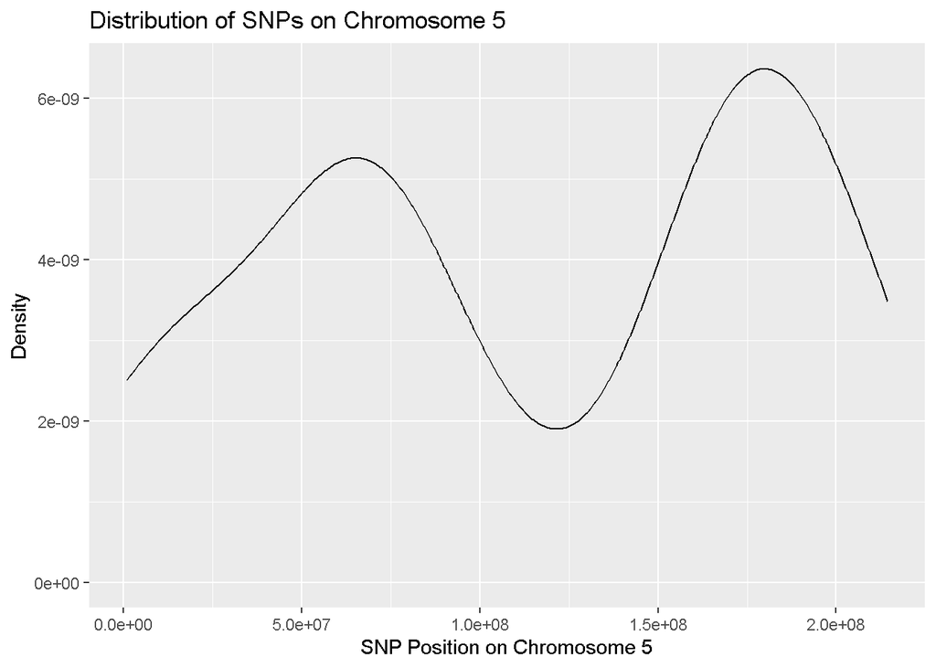

```r
ggplot(data = cut_snp_data_filtered[cut_snp_data_filtered$Chromosome == 5, ], aes(x = Position)) +
     geom_density() +
     labs(x = "SNP Position on Chromosome 5", y = "Density") +
     ggtitle("Distribution of SNPs on Chromosome 5")
```

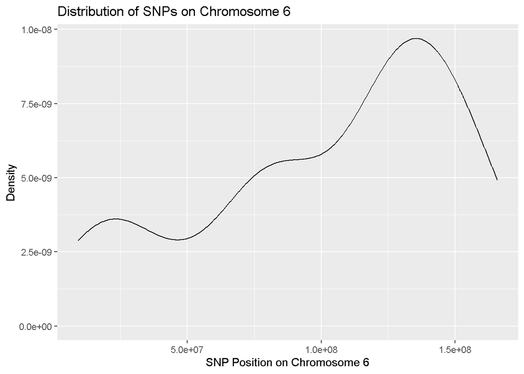

```r
ggplot(data = cut_snp_data_filtered[cut_snp_data_filtered$Chromosome == 6, ], aes(x = Position)) +
     geom_density() +
     labs(x = "SNP Position on Chromosome 6", y = "Density") +
     ggtitle("Distribution of SNPs on Chromosome 6")
```

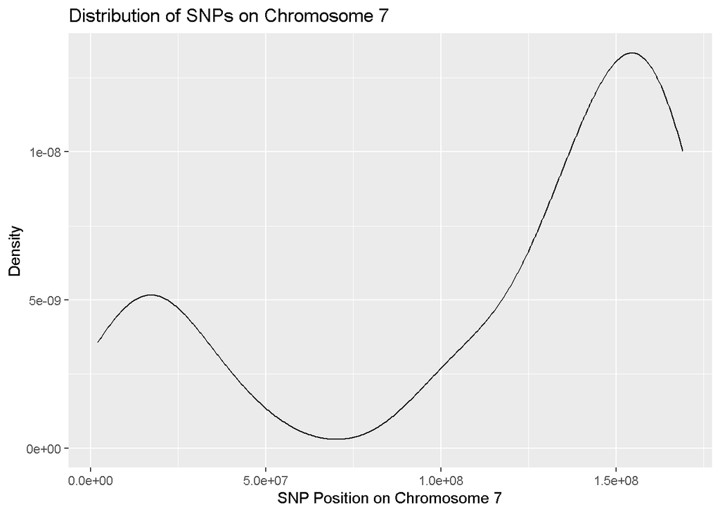

```r
ggplot(data = cut_snp_data_filtered[cut_snp_data_filtered$Chromosome == 7, ], aes(x = Position)) +
     geom_density() +
     labs(x = "SNP Position on Chromosome 7", y = "Density") +
     ggtitle("Distribution of SNPs on Chromosome 7")
```

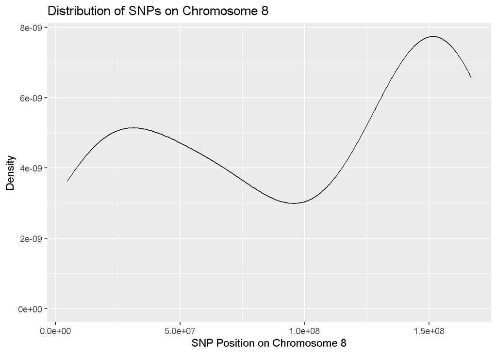

```r
ggplot(data = cut_snp_data_filtered[cut_snp_data_filtered$Chromosome == 8, ], aes(x = Position)) +
     geom_density() +
     labs(x = "SNP Position on Chromosome 8", y = "Density") +
     ggtitle("Distribution of SNPs on Chromosome 8")
```

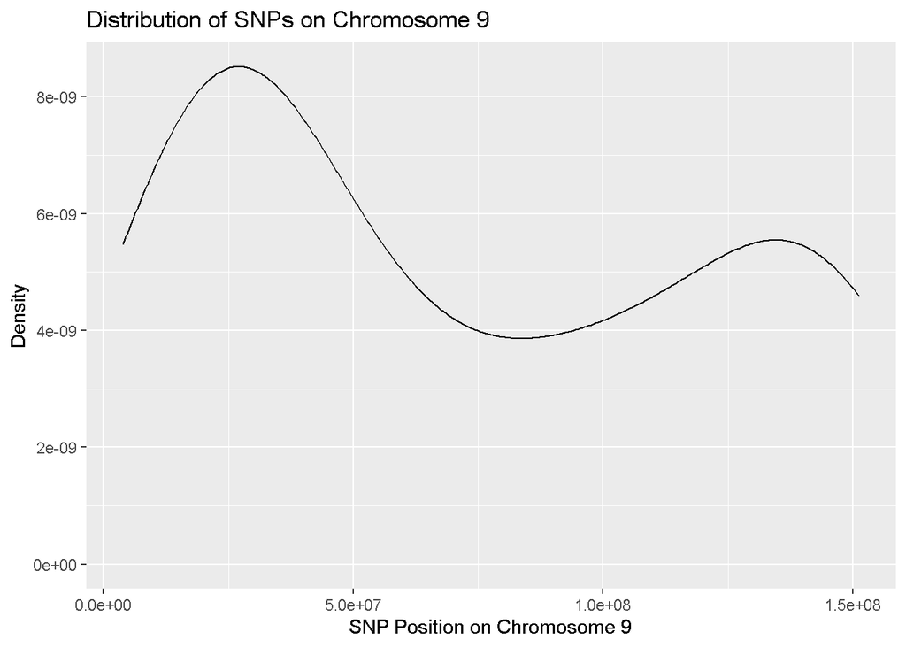

```r
ggplot(data = cut_snp_data_filtered[cut_snp_data_filtered$Chromosome == 9, ], aes(x = Position)) +
     geom_density() +
     labs(x = "SNP Position on Chromosome 9", y = "Density") +
     ggtitle("Distribution of SNPs on Chromosome 9")
```

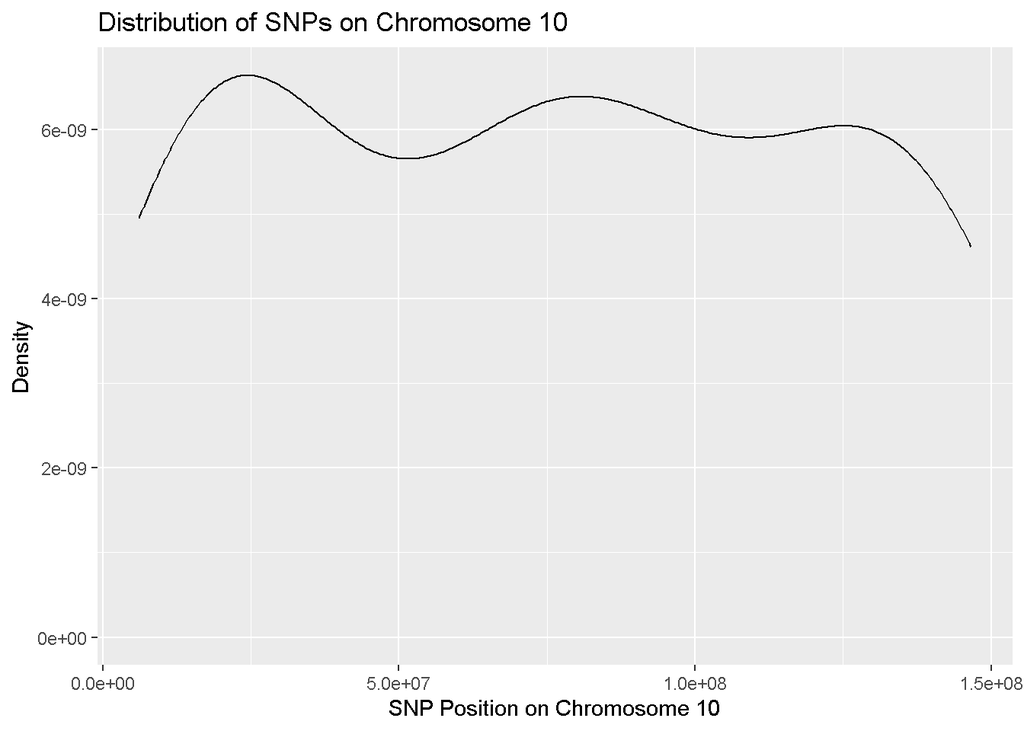

```r
ggplot(data = cut_snp_data_filtered[cut_snp_data_filtered$Chromosome == 10, ], aes(x = Position)) +
     geom_density() +
     labs(x = "SNP Position on Chromosome 10", y = "Density") +
     ggtitle("Distribution of SNPs on Chromosome 10")
```

**density distribution across the 10 chromosomes**

creating a facetted density plot using “cut_snp_data_filtered”, which displays the density of SNP positions for each chromosome. The facets are arranged in a grid with five columns, and each facet is labeled with the corresponding chromosome.

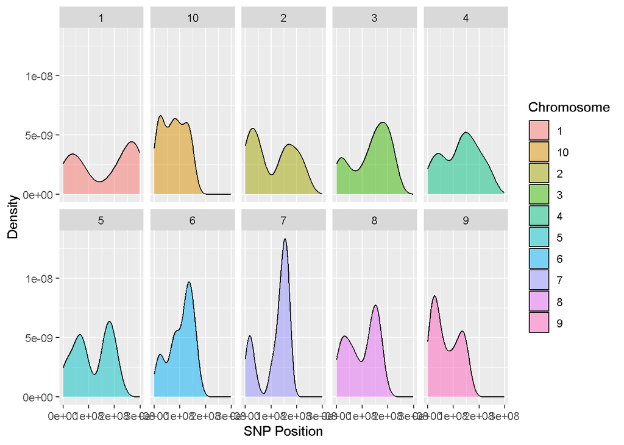

```r
library(tidyr)
ggplot(data = cut_snp_data_filtered, aes(x = Position, fill = factor(Chromosome))) +
     geom_density(alpha = 0.5) +
     scale_fill_discrete(name = "Chromosome") +
     labs(x = "SNP Position", y = "Density") +
     facet_wrap(~Chromosome, ncol = 5)
```

**Missing data and amount of heterozygosity**

Reshaping “readable_fang_et_al_genotypes” by pivoting the columns from 4 to the last column of the data frame into two columns: “Sample” and “Genotype”, and then converts the numbers in the “Sample” column from character to numeric.

```r
single_column_fang_et_al_genotypes <- readable_fang_et_al_genotypes %>%
    pivot_longer(cols = 4:length(readable_fang_et_al_genotypes), names_to = "Sample", values_to = "Genotype") %>%
    mutate(Sample = as.numeric(str_extract(Sample, "\\d+")))

write.csv(single_column_fang_et_al_genotypes, "single_column_fang_et_al_genotypes.csv", row.names = FALSE)
```

Sorting Genotype data into “homozygous” ,“heterozygous” and ” missing” in a new column named “type”

```r
sorted_single_column_fang_et_al_genotypes <- single_column_fang_et_al_genotypes %>%
    mutate(
        type = if_else(
            Genotype == "A/A" | Genotype == "C/C" | Genotype == "G/G" | Genotype == "T/T",
            "homozygous",
            if_else(Genotype == "?/?", "missing", "heterozygous")
        )
    )

write.csv(sorted_single_column_fang_et_al_genotypes, "sorted_single_column_fang_et_al_genotypes.csv", row.names = FALSE)
```

calculating summary statistics in “sorted_single_column_fang_et_al_genotypes”, including the total number of sites, the number of homozygous, heterozygous, and missing sites, as well as the proportions of each site type for each sample.

```r
sample_summary_data <- sorted_single_column_fang_et_al_genotypes %>%
  group_by(Sample_ID) %>%
  summarize(
    total_sites = n(),
    homozygous_sites = sum(type == "homozygous"),
    heterozygous_sites = sum(type == "heterozygous"),
    missing_sites = sum(type == "missing"),
    prop_homozygous = homozygous_sites / total_sites,
    prop_heterozygous = heterozygous_sites / total_sites,
    prop_missing = missing_sites / total_sites
  )
write.csv(sample_summary_data, "sample_summary_data.csv", row.names = FALSE)
```

Creating a stacked bar plot using the summarized data frame “sample_summary_data”, which displays the proportion of homozygous, heterozygous, and missing sites for each sample ID.

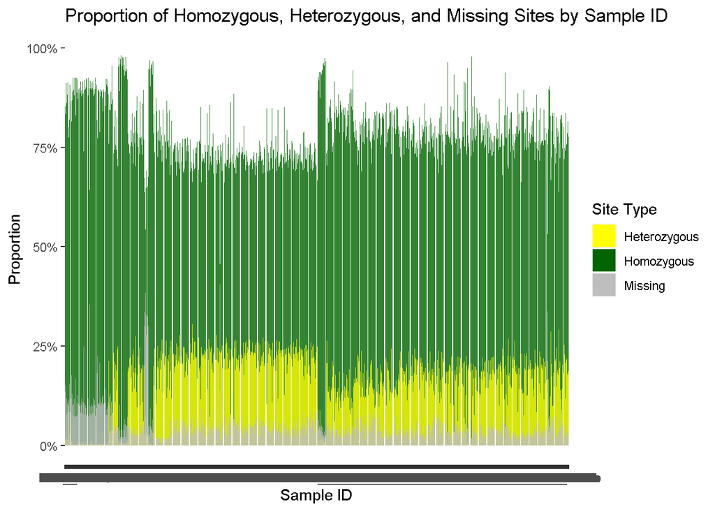

```r
ggplot(sample_summary_data, aes(x = Sample_ID)) +
    geom_bar(aes(y = prop_homozygous, fill = "Homozygous"), alpha = 0.8, stat = "identity") +
    geom_bar(aes(y = prop_heterozygous, fill = "Heterozygous"), alpha = 0.8, stat = "identity") +
    geom_bar(aes(y = prop_missing, fill = "Missing"), alpha = 0.8, stat = "identity") +
    scale_fill_manual(values = c("Homozygous" = "darkgreen", "Heterozygous" = "yellow", "Missing" = "gray")) +
    scale_y_continuous(labels = scales::percent_format(accuracy = 1)) +
    labs(x = "Sample ID", y = "Proportion", fill = "Site Type",
         title = "Proportion of Homozygous, Heterozygous, and Missing Sites by Sample ID")
```

Calculating summary statistics in “sorted_single_column_fang_et_al_genotypes”, including the total number of sites, the number of homozygous, heterozygous, and missing sites, as well as the proportions of each site type for each Group.

```r
Group_summary_data <- sorted_single_column_fang_et_al_genotypes %>%
     group_by(Group) %>%
     summarize(
         total_sites = n(),
         homozygous_sites = sum(type == "homozygous"),
         heterozygous_sites = sum(type == "heterozygous"),
         missing_sites = sum(type == "missing"),
         prop_homozygous = homozygous_sites / total_sites,
         prop_heterozygous = heterozygous_sites / total_sites,
         prop_missing = missing_sites / total_sites
     )
write.csv(Group_summary_data, "Group_summary_data.csv", row.names = FALSE)
```

Creating a stacked bar plot using the summarized data frame “Group_summary_data.csv”, which displays the proportion of homozygous, heterozygous, and missing sites for each Group.

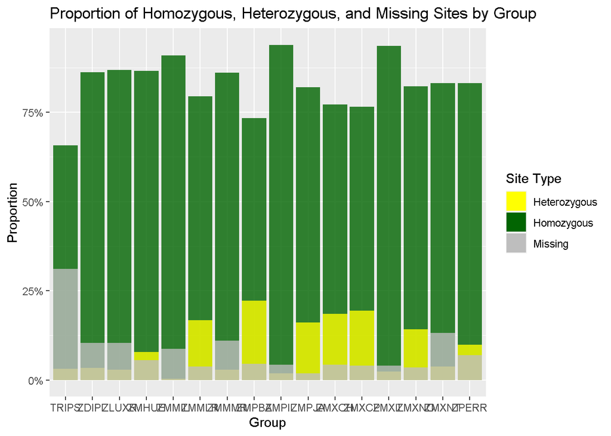

```r
ggplot(Group_summary_data, aes(x = Group)) +
  geom_bar(aes(y = prop_homozygous, fill = "Homozygous"), alpha = 0.8, stat = "identity") +
  geom_bar(aes(y = prop_heterozygous, fill = "Heterozygous"), alpha = 0.8, stat = "identity") +
  geom_bar(aes(y = prop_missing, fill = "Missing"), alpha = 0.8, stat = "identity") +
  scale_fill_manual(values = c("Homozygous" = "darkgreen", "Heterozygous" = "yellow", "Missing" = "gray")) +
  scale_y_continuous(labels = scales::percent_format(accuracy = 1)) +
  labs(x = "Group", y = "Proportion", fill = "Site Type",
       title = "Proportion of Homozygous, Heterozygous, and Missing Sites by Group")
```

### My own visualization

**Proportion of homozygous, heterozygous and missing data across all groups**

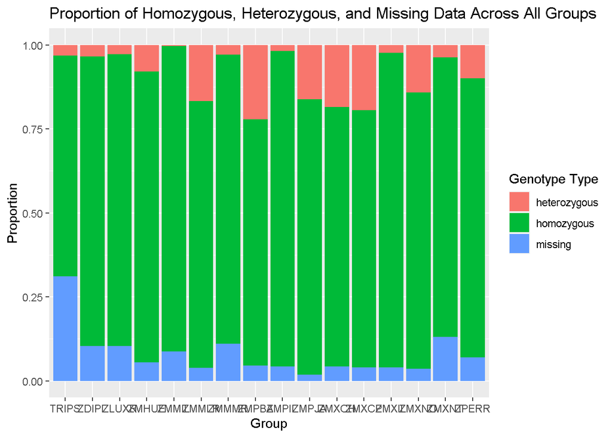

```r
ggplot(sorted_single_column_fang_et_al_genotypes, aes(x = Group, fill = type)) +
    geom_bar(position = "fill") +
    labs(x = "Group", y = "Proportion", fill = "Genotype Type") +
    ggtitle("Proportion of Homozygous, Heterozygous, and Missing Data Across All Groups")
```